# Final Project

Linxi Li T00622714

2022-12-03

```r
#install.packages("mice")
library(mice)
library(VIM)
```

## Create data with 50 rows and two columns

```r
data <- read.csv("/Users/ccc/Desktop/create data1.csv")
head(data)
```

```
##   Y  X
## 1 1  2
## 2 1  4
## 3 0  8
## 4 1 NA
## 5 1  8
## 6 1  3
```

## Column X has some missing data

I am going to show the plot of how the data missing, the red spot represents the missing data

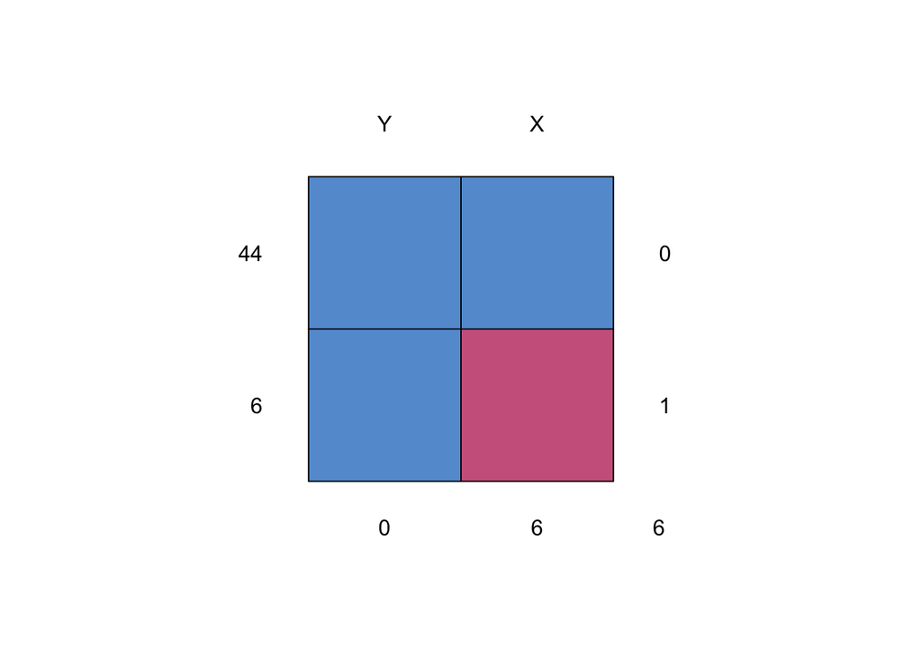

```
##    Y X
## 44 1 1 0
## 6  1 0 1
##    0 6 6
```

```r
md.pattern(data)
```

```r
md.pairs(data)
```

```
## $rr
##    Y  X
## Y 50 44
## X 44 44
##
## $rm
##   Y X
## Y 0 6
## X 0 0
##
## $mr
##   Y X
## Y 0 0
## X 6 0
##
## $mm
##   Y X
## Y 0 0
## X 0 6
```

We can also draw the data distribution of each column of the data set.

In the figure, the red color indicates the missing values, and the transition colors from black to gray to white indicate the different values, the more transition colors indicate the more scattered data values, and the less transition colors indicate the more concentrated data values.

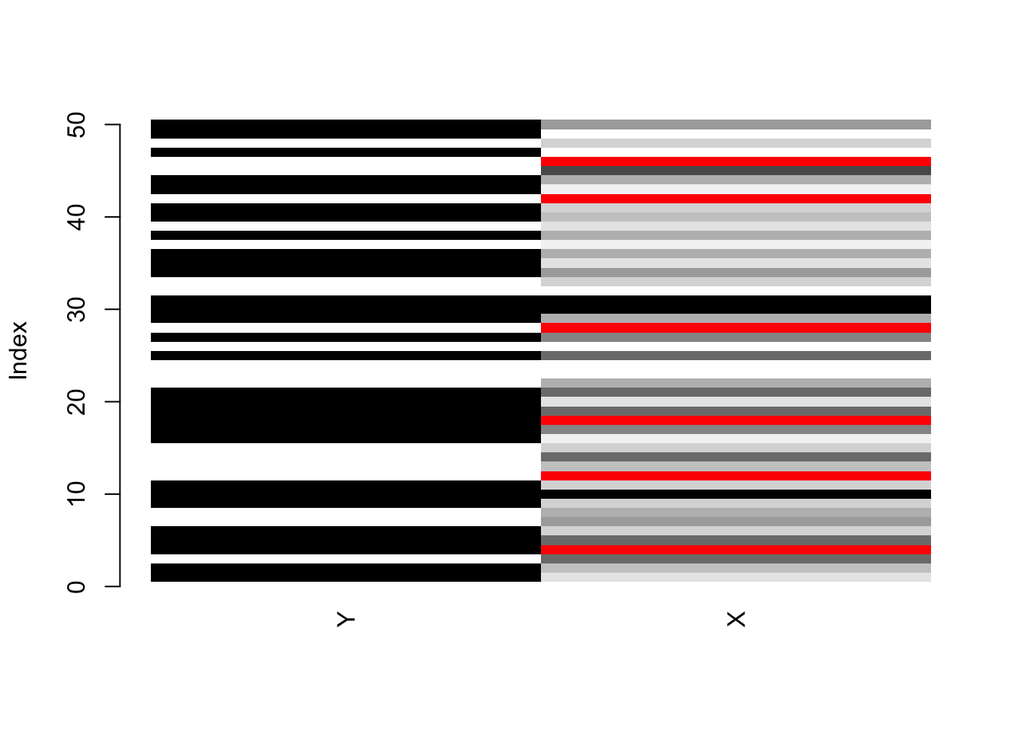

```
##
## Click in a column to sort by the corresponding variable.
## To regain use of the VIM GUI and the R console, click outside the plot region.
```

```r
matrixplot(data)
```

Next, we use the mice() function, which is used to populate the data

## Distribution of 100 imputation

```r
imputed_Data100 <- mice(data, m=100, maxit = 5, method = 'pmm', seed = 500)
fit100=with(imputed_Data100,lm(Y ~ X))
summary(fit100)

#result hide
```

note that: m, the number of fill matrices for the multi-fill method, default is 5 maxit, the maximum number of iterations, default is 5 method, the method used to fill, and pmm is predictive mean matching. We can use methods(mice) to see what methods are available.

Now, let’s see the results of 100 imputation.

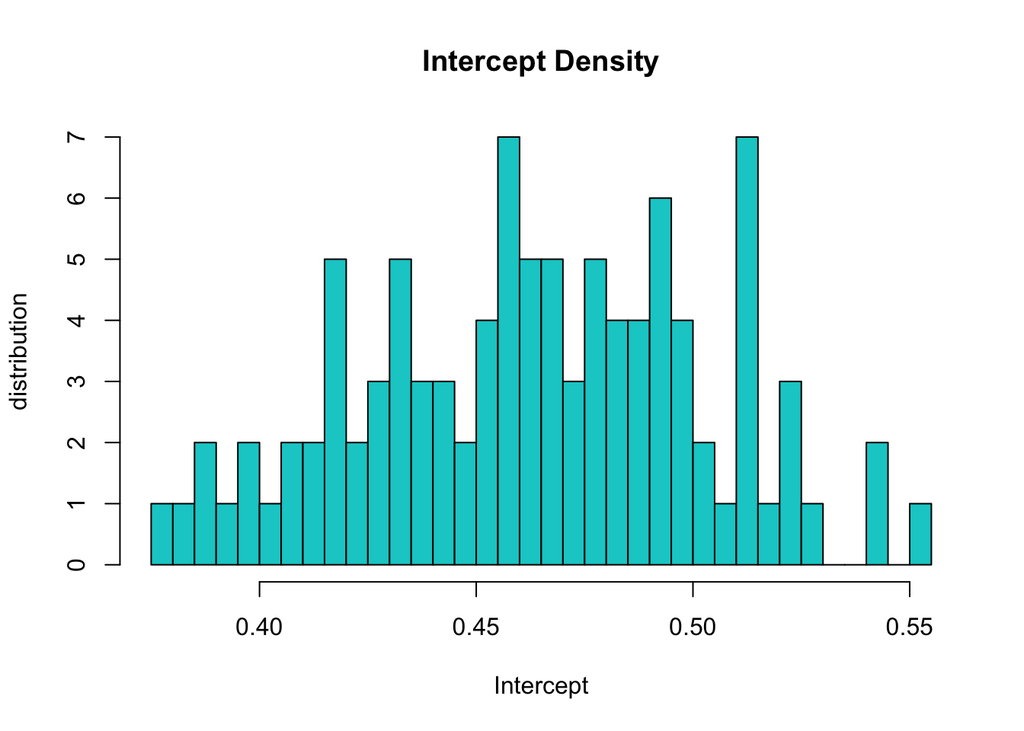

```r
d = matrix(nrow = 100, ncol = 4)
for (i in seq(1,100)){
  for (j in seq(1,2)){
    d[i,j]=fit100$analyses[[i]][[1]][[j]]
  }
}
hist(d[,1],breaks=50,xlab="Intercept", ylab="distribution",main="Intercept Density",
     col = "cyan3")
```

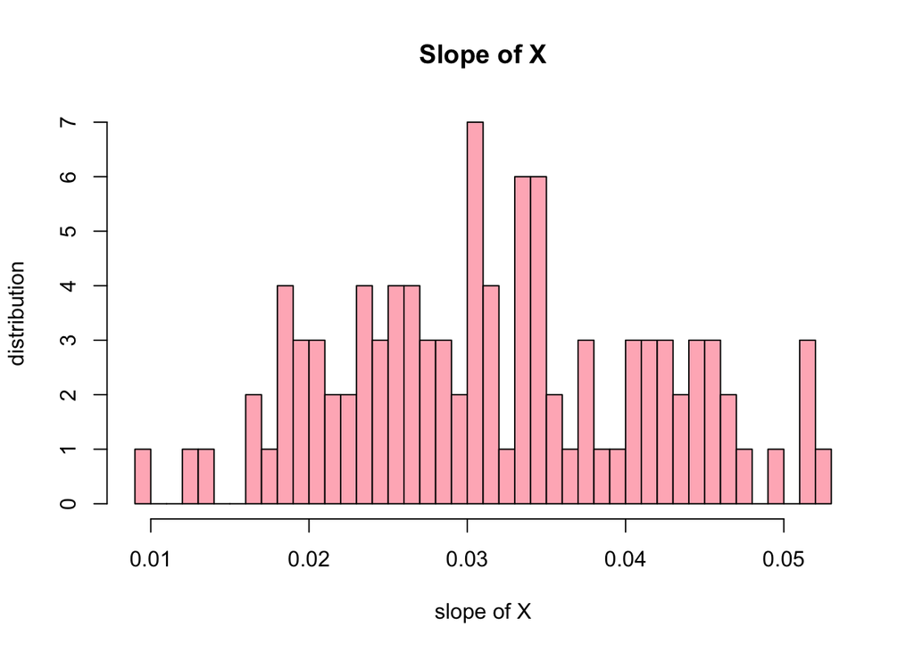

```r
hist(d[,2],breaks=50,xlab="slope of X", ylab="distribution",main="Slope of X",
     col="lightpink")
```

Now, we do ten imputations and then select the one with the best results by comparing their $R^2$, which is used to make our data.

```r
imputed_Data <- mice(data, m=10, maxit = 5, method = 'pmm', seed = 500)

#result hide
```

## View the result of imputation:

```r
imputed_Data$imp
```

```
## $Y
##  [1] 1  2  3  4  5  6  7  8  9  10
## <0 rows> (or 0-length row.names)
##
## $X
##    1 2 3 4  5 6 7 8  9 10
## 4  8 5 0 7  4 0 3 8  0  1
## 12 5 6 0 4  7 0 3 4  5  0
## 18 6 5 3 7  5 7 6 8 10  5
## 28 0 6 0 3 10 0 3 4  5  4
## 42 0 5 0 5  5 3 1 0  0  0
## 46 0 0 6 3  0 0 6 0  3  4
```

View the plot of Sub-panel observations, grouped by independent individual indicators, were populated for the 10 groups of data.

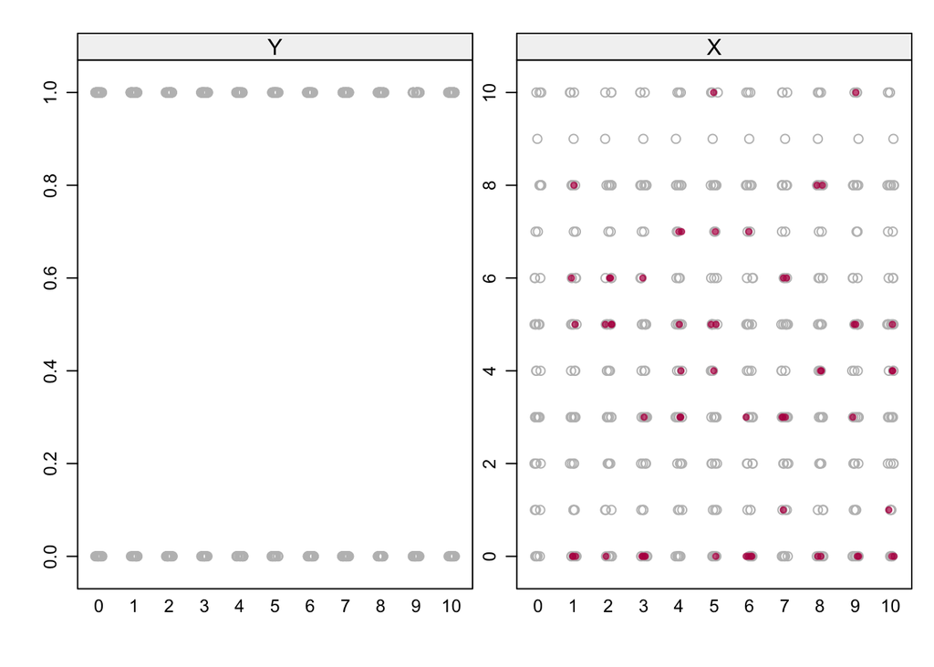

```r
stripplot(imputed_Data, col=c("grey",mdc(2)),pch=c(1,20))
```

## Analyze the results and optimize the model

```r
fit=with(imputed_Data,lm(Y ~ X))
summary(fit)
```

```
## # A tibble: 20 × 6
##    term        estimate std.error statistic  p.value  nobs
##    <chr>          <dbl>     <dbl>     <dbl>    <dbl> <int>
##  1 (Intercept)   0.397     0.115      3.47  0.00111     50
##  2 X             0.0478    0.0218     2.19  0.0335      50
##  3 (Intercept)   0.457     0.125      3.65  0.000641    50
##  4 X             0.0326    0.0236     1.38  0.175       50
##  5 (Intercept)   0.450     0.113      3.99  0.000228    50
##  6 X             0.0371    0.0222     1.67  0.101       50
##  7 (Intercept)   0.423     0.125      3.37  0.00147     50
##  8 X             0.0398    0.0236     1.68  0.0990      50
##  9 (Intercept)   0.497     0.125      3.99  0.000224    50
## 10 X             0.0229    0.0230     0.996 0.324       50
## 11 (Intercept)   0.422     0.112      3.79  0.000427    50
## 12 X             0.0437    0.0218     2.00  0.0507      50
## 13 (Intercept)   0.439     0.123      3.58  0.000807    50
## 14 X             0.0375    0.0236     1.59  0.118       50
## 15 (Intercept)   0.398     0.117      3.40  0.00138     50
## 16 X             0.0465    0.0221     2.10  0.0407      50
## 17 (Intercept)   0.451     0.119      3.80  0.000404    50
## 18 X             0.0344    0.0224     1.54  0.130       50
## 19 (Intercept)   0.437     0.117      3.74  0.000487    50
## 20 X             0.0394    0.0228     1.73  0.0909      50
```

```r
pooled=pool(fit)
pool.r.squared(fit)
```

```
##            est       lo 95     hi 95       fmi
## R^2 0.05590927 0.003918815 0.2465542 0.1163204
```

```r
completeData1 <- complete(imputed_Data,1)
data1 <- lm(Y ~ X, data=completeData1)
summary(data1)
```

```
##
## Call:
## lm(formula = Y ~ X, data = completeData1)
##
## Residuals:
##     Min      1Q  Median      3Q     Max
## -0.8275 -0.4332  0.2203  0.3995  0.6026
##
## Coefficients:
##             Estimate Std. Error t value Pr(>|t|)
## (Intercept)  0.39738    0.11450   3.471  0.00111 **
## X            0.04779    0.02183   2.189  0.03346 *
## ---
## Signif. codes:  0 '***' 0.001 '**' 0.01 '*' 0.05 '.' 0.1 ' ' 1
##
## Residual standard error: 0.4768 on 48 degrees of freedom
## Multiple R-squared:  0.09079,    Adjusted R-squared:  0.07185
## F-statistic: 4.793 on 1 and 48 DF,  p-value: 0.03346
```

```r
completeData2 <- complete(imputed_Data,2)
data2 <- lm(Y ~ X, data=completeData2)
summary(data2)
```

```
##
## Call:
## lm(formula = Y ~ X, data = completeData2)
##
## Residuals:
##     Min      1Q  Median      3Q     Max
## -0.7498 -0.5463  0.2828  0.4049  0.5433
##
## Coefficients:
##             Estimate Std. Error t value Pr(>|t|)
## (Intercept)  0.45674    0.12505   3.652 0.000641 ***
## X            0.03256    0.02365   1.377 0.174999
## ---
## Signif. codes:  0 '***' 0.001 '**' 0.01 '*' 0.05 '.' 0.1 ' ' 1
##
## Residual standard error: 0.4904 on 48 degrees of freedom
## Multiple R-squared:  0.03798,    Adjusted R-squared:  0.01794
## F-statistic: 1.895 on 1 and 48 DF,  p-value: 0.175
```

```r
completeData3 <- complete(imputed_Data,3)
data3 <- lm(Y ~ X, data=completeData3)
summary(data3)
```

```
##
## Call:
## lm(formula = Y ~ X, data = completeData3)
##
## Residuals:
##     Min      1Q  Median      3Q     Max
## -0.7840 -0.4780  0.2531  0.4293  0.5498
##
## Coefficients:
##             Estimate Std. Error t value Pr(>|t|)
## (Intercept)  0.45016    0.11296   3.985 0.000228 ***
## X            0.03709    0.02219   1.672 0.101095
## ---
## Signif. codes:  0 '***' 0.001 '**' 0.01 '*' 0.05 '.' 0.1 ' ' 1
##
## Residual standard error: 0.4861 on 48 degrees of freedom
## Multiple R-squared:  0.05502,    Adjusted R-squared:  0.03533
## F-statistic: 2.795 on 1 and 48 DF,  p-value: 0.1011
```

```r
completeData4 <- complete(imputed_Data,4)
data4 <- lm(Y ~ X, data=completeData4)
summary(data4)
```

```
##
## Call:
## lm(formula = Y ~ X, data = completeData4)
##
## Residuals:
##     Min      1Q  Median      3Q     Max
## -0.7814 -0.5427  0.2584  0.4076  0.5766
##
## Coefficients:
##             Estimate Std. Error t value Pr(>|t|)
## (Intercept)  0.42338    0.12546   3.374  0.00147 **
## X            0.03978    0.02364   1.683  0.09896 .
## ---
## Signif. codes:  0 '***' 0.001 '**' 0.01 '*' 0.05 '.' 0.1 ' ' 1
##
## Residual standard error: 0.4859 on 48 degrees of freedom
## Multiple R-squared:  0.05569,    Adjusted R-squared:  0.03602
## F-statistic: 2.831 on 1 and 48 DF,  p-value: 0.09896
```

```r
completeData5 <- complete(imputed_Data,5)
data5 <- lm(Y ~ X, data=completeData5)
summary(data5)
```

```
##
## Call:
## lm(formula = Y ~ X, data = completeData5)
##
## Residuals:
##     Min      1Q  Median      3Q     Max
## -0.7265 -0.5604  0.3193  0.4110  0.5027
##
## Coefficients:
##             Estimate Std. Error t value Pr(>|t|)
## (Intercept)  0.49732    0.12461   3.991 0.000224 ***
## X            0.02292    0.02301   0.996 0.324276
## ---
## Signif. codes:  0 '***' 0.001 '**' 0.01 '*' 0.05 '.' 0.1 ' ' 1
##
## Residual standard error: 0.4949 on 48 degrees of freedom
## Multiple R-squared:  0.02025,    Adjusted R-squared:  -0.0001656
## F-statistic: 0.9919 on 1 and 48 DF,  p-value: 0.3243
```

```r
completeData6 <- complete(imputed_Data,6)
data6 <- lm(Y ~ X, data=completeData6)
summary(data6)
```

```
##
## Call:
## lm(formula = Y ~ X, data = completeData6)
##
## Residuals:
##     Min      1Q  Median      3Q     Max
## -0.8160 -0.4553  0.2277  0.4026  0.5775
##
## Coefficients:
##             Estimate Std. Error t value Pr(>|t|)
## (Intercept)  0.42247    0.11161   3.785 0.000427 ***
## X            0.04373    0.02181   2.005 0.050661 .
## ---
## Signif. codes:  0 '***' 0.001 '**' 0.01 '*' 0.05 '.' 0.1 ' ' 1
##
## Residual standard error: 0.4803 on 48 degrees of freedom
## Multiple R-squared:  0.07725,    Adjusted R-squared:  0.05803
## F-statistic: 4.019 on 1 and 48 DF,  p-value: 0.05066
```

```r
completeData7 <- complete(imputed_Data,7)
data7 <- lm(Y ~ X, data=completeData7)
summary(data7)
```

```
##
## Call:
## lm(formula = Y ~ X, data = completeData7)
##
## Residuals:
##     Min      1Q  Median      3Q     Max
## -0.7763 -0.5419  0.2612  0.4113  0.5613
##
## Coefficients:
##             Estimate Std. Error t value Pr(>|t|)
## (Intercept)  0.43869    0.12266   3.576 0.000807 ***
## X            0.03751    0.02360   1.590 0.118453
## ---
## Signif. codes:  0 '***' 0.001 '**' 0.01 '*' 0.05 '.' 0.1 ' ' 1
##
## Residual standard error: 0.4873 on 48 degrees of freedom
## Multiple R-squared:  0.05002,    Adjusted R-squared:  0.03023
## F-statistic: 2.527 on 1 and 48 DF,  p-value: 0.1185
```

```r
completeData8 <- complete(imputed_Data,8)
data8 <- lm(Y ~ X, data=completeData8)
summary(data8)
```

```
##
## Call:
## lm(formula = Y ~ X, data = completeData8)
##
## Residuals:
##     Min      1Q  Median      3Q     Max
## -0.8165 -0.4797  0.2300  0.4042  0.6016
##
## Coefficients:
##             Estimate Std. Error t value Pr(>|t|)
## (Intercept)  0.39836    0.11733   3.395  0.00138 **
## X            0.04646    0.02209   2.104  0.04069 *
## ---
## Signif. codes:  0 '***' 0.001 '**' 0.01 '*' 0.05 '.' 0.1 ' ' 1
##
## Residual standard error: 0.4784 on 48 degrees of freedom
## Multiple R-squared:  0.0844, Adjusted R-squared:  0.06533
## F-statistic: 4.425 on 1 and 48 DF,  p-value: 0.04069
```

```r
completeData9 <- complete(imputed_Data,9)
data9 <- lm(Y ~ X, data=completeData9)
summary(data9)
```

```
##
## Call:
## lm(formula = Y ~ X, data = completeData9)
##
## Residuals:
##     Min      1Q  Median      3Q     Max
## -0.7610 -0.5460  0.2734  0.4110  0.5486
##
## Coefficients:
##             Estimate Std. Error t value Pr(>|t|)
## (Intercept)  0.45143    0.11870   3.803 0.000404 ***
## X            0.03439    0.02235   1.539 0.130471
## ---
## Signif. codes:  0 '***' 0.001 '**' 0.01 '*' 0.05 '.' 0.1 ' ' 1
##
## Residual standard error: 0.4881 on 48 degrees of freedom
## Multiple R-squared:  0.047,  Adjusted R-squared:  0.02715
## F-statistic: 2.367 on 1 and 48 DF,  p-value: 0.1305
```

```r
completeData10 <- complete(imputed_Data,10)
data10 <- lm(Y~X, data=completeData10)
summary(data10)
```

```
##
## Call:
## lm(formula = Y ~ X, data = completeData10)
##
## Residuals:
##     Min      1Q  Median      3Q     Max
## -0.7914 -0.5059  0.2480  0.4055  0.5630
##
## Coefficients:
##             Estimate Std. Error t value Pr(>|t|)
## (Intercept)  0.43697    0.11676   3.742 0.000487 ***
## X            0.03938    0.02282   1.726 0.090852 .
## ---
## Signif. codes:  0 '***' 0.001 '**' 0.01 '*' 0.05 '.' 0.1 ' ' 1
##
## Residual standard error: 0.4852 on 48 degrees of freedom
## Multiple R-squared:  0.05841,    Adjusted R-squared:  0.0388
## F-statistic: 2.978 on 1 and 48 DF,  p-value: 0.09085
```

By checking the $R^2$, I am going to use the imputation 1, as our missing data. However, since the response variable is only 0 or 1, we determined that changing the data is suitable for logistic regression. Therefore, I will perform a logistic regression on this data and find the maximum likelihood in the next steps by applying to Optim() and newton method, with the imputation data1 as my final data.

## I can assign x and y from the data , such that:

```r
x <- completeData1$X
y <- completeData1$Y
```

In this project, at the beginning, I used the glm() to estimate the MLE of my data by using the family of “binomial”. Usually, glm() will give us a more realistic answer. Therefore, we can find out the different by comparing the answers given by optim(), Newton’s method to the glm().

## glm()

```r
mylogit <- glm(y ~ x, family = "binomial"(link = "logit"))
mylogit
```

```
##
## Call:  glm(formula = y ~ x, family = binomial(link = "logit"))
##
## Coefficients:
## (Intercept)            x
##     -0.4604       0.2152
##
## Degrees of Freedom: 49 Total (i.e. Null);  48 Residual
## Null Deviance:       67.3
## Residual Deviance: 62.58     AIC: 66.58
```

As we know that, b0 is intercept, and b1 represents the slope, so we can get our result from glm() that b0 is -0.4604, and b1 is 0.2152.

After getting the result from glm(), we can start using optim() to get MLE.

## optim()

```r
#MLE for logistic

nlogL_logstic <- function(paravec){
  # paravec[1] - b0
  # paravec[2] - b1
  sum(y*paravec[1])+sum(y*paravec[2]*x)-sum(log(1+exp(paravec[1]+paravec[2]*x)))

}

MLE = optim(c(0,0), #because we have two parameters in the function;
            fn=nlogL_logstic,
            method = "L-BFGS-B",
            control = list(fnscale = -1),
            hessian = FALSE)
MLE
```

```
## $par
## [1] -0.4603692  0.2151646
##
## $value
## [1] -31.28791
##
## $counts
## function gradient
##       15       15
##
## $convergence
## [1] 0
##
## $message
## [1] "CONVERGENCE: REL_REDUCTION_OF_F <= FACTR*EPSMCH"
```

The optim() gives the result of b0 is -0.4603692, and b1 is 0.2151646, which are very much close to the glm() result.

Finally, we use Newton’s Method to compare by using the derivative of the log likelihood function and derivative of the score function.

## Newton

```r
#Newton of b0 and b1
nlogL_log <- function(b0,b1){
  # b0
  # b1
  sum(y*(b0+b1*x))-sum(log(1+exp(b0+b1*x)))
}

nor_MLE_of_Newtown <- function (x, itr, b00=0,b11=0) {
  # input: x-vector of observations; itr- iteration times; b00,b11 - initial value
  # output: MLE estimate and maximum log-likelihood value
  b0<- rep(0,itr+1)
  b1<- rep(0,itr+1)
  b0[1] <- b00
  b1[1] <- b11
  for (i in 1:itr){
    #b[n+1] = b[n] - l(bn)/l'(bn)
    b0[i+1] = b0[i] - (sum(y)-sum(exp(b0[i]+b1[i]*x)/(1+exp(b0[i]+b1[i]*x))))/
      (-sum((exp(b0[i]+b1[i]*x))/(exp(b0[i]+b1[i]*x)+1)^2))

    #sigma2[i+1] = sigma[i] - sigma[i] + (1/n * sum((xi - mu)^2))
    b1[i+1]=b1[i] - (sum(x*y)-sum(x*exp(b0[i]+b1[i]*x)/(1+exp(b0[i]+b1[i]*x))))/
      (-sum(((x^2)*exp(b0[i]+b1[i]*x))/(exp(b0[i]+b1[i]*x)^2)))

  }
  data.frame(b0=b0, b1=b1,log.lik.value=nlogL_log(b0,b1))
}


n<-x
nor_MLE_of_Newtown(n,150) # iterate 150 times
```

```
##              b0         b1 log.lik.value
## 1    0.00000000 0.00000000     -94.07744
## 2    0.40000000 0.03197674     -94.07744
## 3    0.26885328 0.04950306     -94.07744
## 4    0.19739952 0.06816631     -94.07744
## 5    0.12034222 0.08467369     -94.07744
## 6    0.05301745 0.09984577     -94.07744
## 7   -0.00843215 0.11351040     -94.07744
## 8   -0.06336545 0.12579333     -94.07744
## 9   -0.11242579 0.13676232     -94.07744
## 10  -0.15598101 0.14651788     -94.07744
## 11  -0.19451582 0.15515917     -94.07744
## 12  -0.22849072 0.16278822     -94.07744
## 13  -0.25836265 0.16950410     -94.07744
## 14  -0.28456385 0.17540158     -94.07744
```

[output cut: 137 more lines]

After iterating 150 times, we can see our result of b0 is -0.46037541, and b1 is 0.21516576, which are also close to glm() result.